# Hoja de Trabajo 1

### 4.1. ¿Cuáles son las 10 películas que contaron con más presupuesto?

```r
budget<-movies[with(movies,order(-movies$budget)),1:6]
head(budget,10)
```

```
##          id   imdb_id popularity    budget    revenue
## 2245  46528 tt1032751   0.250540 425000000   11087569
## 3376   1865 tt1298650   4.955130 380000000 1021683000
## 7388    285 tt0449088   4.965391 300000000  961000000
## 15    99861 tt2395427   5.944927 280000000 1405035767
## 6571   1452 tt0348150   1.957331 270000000  391081192
## 1930  38757 tt0398286   2.865684 260000000  591794936
## 4412  49529 tt0401729   1.588457 260000000  284139100
## 7395    559 tt0413300   2.520912 258000000  890871626
## 5509  57201 tt1210819   1.214510 255000000   89289910
## 635  122917 tt2310332  10.174599 250000000  955119788
##                                   original_title
## 2245                           The Warrior's Way
## 3376 Pirates of the Caribbean: On Stranger Tides
## 7388    Pirates of the Caribbean: At World's End
## 15                       Avengers: Age of Ultron
## 6571                            Superman Returns
## 1930                                     Tangled
## 4412                                 John Carter
## 7395                                Spider-Man 3
## 5509                             The Lone Ranger
## 635    The Hobbit: The Battle of the Five Armies
```

### 4.2. ¿Cuáles son las 10 películas que más ingresos tuvieron?

```r
budget<-movies[with(movies,order(-movies$revenue)),1:6]
head(budget,10)
```

```
##          id   imdb_id popularity    budget    revenue
## 1387  19995 tt0499549   9.432768 237000000 2781505847
## 4    140607 tt2488496  11.173104 200000000 2068178225
## 5232    597 tt0120338   4.355219 200000000 1845034188
## 4362  24428 tt0848228   7.637767 220000000 1519557910
## 1    135397 tt0369610  32.985763 150000000 1513528810
## 5    168259 tt2820852   9.335014 190000000 1506249360
## 15    99861 tt2395427   5.944927 280000000 1405035767
## 3375  12445 tt1201607   5.711315 125000000 1327817822
## 5423 109445 tt2294629   6.112766 150000000 1274219009
## 5426  68721 tt1300854   4.946136 200000000 1215439994
##                                    original_title
## 1387                                       Avatar
## 4                    Star Wars: The Force Awakens
## 5232                                      Titanic
## 4362                                 The Avengers
## 1                                  Jurassic World
## 5                                       Furious 7
## 15                        Avengers: Age of Ultron
## 3375 Harry Potter and the Deathly Hallows: Part 2
## 5423                                       Frozen
## 5426                                   Iron Man 3
```

### 4.3. ¿Cuál es la película que más votos tuvo?

```r
budget<-movies[with(movies,order(-movies$vote_count)),1:6]
head(budget$original_title,1)
```

```
## [1] "Inception"
```

### 4.4.¿Cuál es la peor película de acuerdo a los votos de todos los usuarios?

```r
budget<-movies[with(movies,order(movies$vote_average)),1:6]
head(budget$original_title,1)
```

```
## [1] "Transmorphers"
```

### 4.5.¿Cuántas películas se hicieron cada año?¿En qué año se hicieron más películas? Haga un gráfico de barras

[figure not shown]

```r
movies$cuenta <- 1
years <- aggregate (movies$cuenta, by = list(movies$release_year), FUN = sum)
vec <- c (years)

colors = c("black","red","blue","grey","orange","pink","purple")
barplot(vec$x, names.arg = vec$Group.1, xlab = "año", ylab ="Cantidad de Licas",main = "Promedio de perdidas",col=colors)
```

### 4.6.¿Cuál es el género principal de las 20 películas más populares?

```r
popularity<-movies[with(movies,order(-movies$popularity)),]
head(popularity$genres,20)
```

```
##  [1] "Action|Adventure|Science Fiction|Thriller"
##  [2] "Action|Adventure|Science Fiction|Thriller"
##  [3] "Adventure|Drama|Science Fiction"
##  [4] "Action|Science Fiction|Adventure"
##  [5] "Adventure|Science Fiction|Thriller"
##  [6] "Action|Adventure|Science Fiction"
##  [7] "Adventure|Action|Science Fiction"
##  [8] "Action|Thriller"
##  [9] "Action|Adventure|Science Fiction|Fantasy"
## [10] "Science Fiction|Adventure|Thriller"
## [11] "Adventure|Fantasy"
## [12] "Action|Adventure|Fantasy|Science Fiction"
## [13] "Action|Thriller|Science Fiction|Mystery|Adventure"
## [14] "Action|Crime|Thriller"
## [15] "Western|Drama|Adventure|Thriller"
## [16] "Drama"
## [17] "Adventure|Family|Animation|Action|Comedy"
## [18] "Science Fiction|Action|Thriller|Adventure"
## [19] "Adventure|Fantasy|Action"
## [20] "Drama|Action|Crime|Thriller"
```

```r
library(tidyr)
category<-popularity %>%separate(genres,c("categoria1","categoria2","categoria3","categoria4"),sep="\\|")
head(category$categoria1,20)
```

```
##  [1] "Action"          "Action"          "Adventure"       "Action"
##  [5] "Adventure"       "Action"          "Adventure"       "Action"
##  [9] "Action"          "Science Fiction" "Adventure"       "Action"
## [13] "Action"          "Action"          "Western"         "Drama"
## [17] "Adventure"       "Science Fiction" "Adventure"       "Drama"
```

### 4.7. ¿Cuál es el género que predomina en el conjunto de datos?

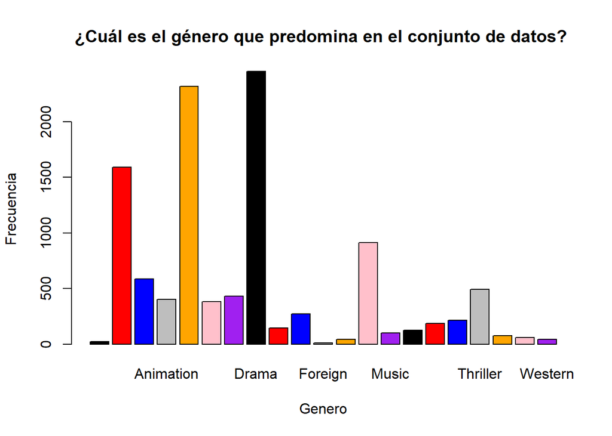

```r
graph <-aggregate(category$cuenta, by=list(category$categoria1), FUN=sum)
vec <- c(graph)

colors = c("black","red","blue","grey","orange","pink","purple")
barplot(vec$x, names.arg = vec$Group.1, xlab = "Genero", ylab ="Frecuencia",main = "¿Cuál es el género que predomina en el conjunto de datos? ",col=colors)
```

El género que predomina en el conjunto de datos es Drama

### 4.8. ¿Las películas de qué género principal obtuvieron mayores ganancias?

```r
ganancias<-aggregate(category$revenue, by=list(category$categoria1), FUN=sum)
ganancias
```

```
##            Group.1           x
## 1                            0
## 2           Action 96606072845
## 3        Adventure 73107006764
## 4        Animation 28797048213
## 5           Comedy 67952461496
## 6            Crime 12706767478
## 7      Documentary   852211592
## 8            Drama 61678301024
## 9           Family  8854452778
## 10         Fantasy 18303948327
## 11         Foreign           0
## 12         History  1951867180
## 13          Horror 15432626119
## 14           Music  2304615926
## 15         Mystery  3019881629
## 16         Romance  7046888501
## 17 Science Fiction 17046401611
## 18        Thriller 13003269735
## 19        TV Movie    42000000
## 20             War  2708551908
## 21         Western  1305819749
```

Las películas de acción fueron las que obtuvieron más ganancias.

### 4.9. ¿Las películas de qué género principal necesitaron mayor presupuesto?

```r
presupuesto2<-aggregate(category$budget, by=list(category$categoria1), FUN=sum)
presupuesto2
```

```
##            Group.1           x
## 1                         5000
## 2           Action 39187934992
## 3        Adventure 23576834285
## 4        Animation  8661435933
## 5           Comedy 24067900257
## 6            Crime  5118189502
## 7      Documentary   186117557
## 8            Drama 25333500351
## 9           Family  2642888200
## 10         Fantasy  6378051854
## 11         Foreign           0
## 12         History   701119005
## 13          Horror  5139861643
## 14           Music  1052200015
## 15         Mystery  1263291518
## 16         Romance  2070494938
## 17 Science Fiction  5373861758
## 18        Thriller  5982757498
## 19        TV Movie    19500000
## 20             War  1347210000
## 21         Western   819713783
```

Las películas de acción fueron las que requirieron de mayor presupuesto.

### 4.10. ¿Quiénes son los 20 mejores directores que hicieron películas altamente calificadas?

```r
votaciones<-category[with(category,order(-category$vote_average)),]
top20 = head(votaciones,30)
director<-aggregate(top20$vote_average, by=list(top20$director), FUN=sum)
director
```

```
##                                        Group.1    x
## 1                                              33.9
## 2                                  Adam Curtis  8.3
## 3                               Andrew Jarecki  8.4
## 4                                Andy Saunders  8.3
## 5                              Anthony Mandler  8.4
## 6                                Carl Tibbetts  8.8
## 7                                  Chris Bould  8.4
## 8                              Claude Lanzmann  8.3
## 9                                  Curt Morgan  8.5
## 10 D.A. Pennebaker|David Dawkins|Chris Hegedus  8.4
## 11                                 Danny Boyle  8.3
## 12                                David Mallet  8.7
## 13                                Dean Wellins  8.3
## 14                            Derek Frankowski  8.8
## 15                        Francis Ford Coppola  8.3
## 16                              Frank Darabont  8.4
## 17                                 James Payne  8.5
## 18                      Jennifer Siebel Newsom  8.9
## 19                              Jonathan Demme  8.4
## 20                  Jorge RamÃƒÂrez SuÃƒÂ¡rez  8.4
## 21                                 Kurt Kuenne  8.3
## 22                                Mark Cousins  9.2
## 23        Martin Scorsese|Michael Henry Wilson  8.5
## 24                      Sam Dunn|Scot McFadyen 16.7
## 25                                Saul Swimmer  8.5
## 26                                 Stan Lathan  8.5
```

### 4.11. ¿Cómo se correlacionan los presupuestos con los ingresos? ¿Los altos presupuestos significan altos ingresos? Haga los gráficos que necesite, histograma, diagrama de dispersión

```r
ingresos <-data.frame(movies$budget,movies$revenue, movies$original_title)

library(MASS)
cor(x=ingresos[,1], y=ingresos[,2])
```

```
## [1] 0.7349007
```

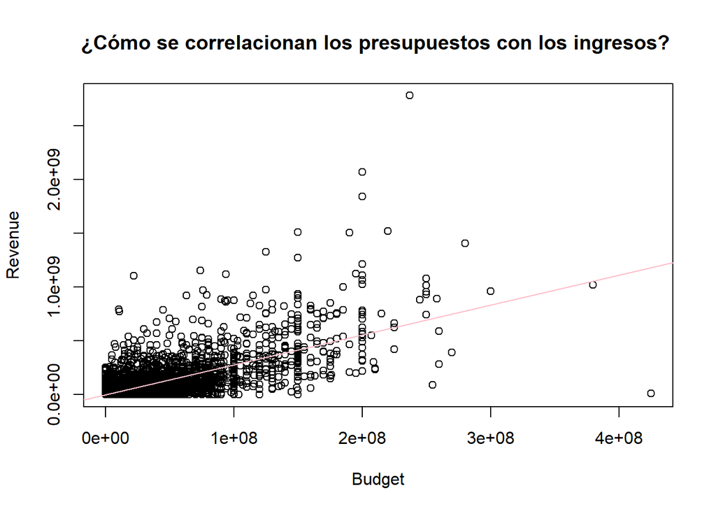

```r
plot(ingresos[,1], ingresos[,2], main="¿Cómo se correlacionan los presupuestos con los ingresos? " ,xlab="Budget", ylab="Revenue")
abline(lm(ingresos[,2]~ingresos[,1]), col="pink")
```